# Reproducible Research

Ruíz Rodríguez Ricardo

26/9/2020

## Loading and preprocessing the data

```r
  activity <- read.csv("activity.csv")
```

```r
  str(activity)
```

```
## 'data.frame':    17568 obs. of  3 variables:
##  $ steps   : int  NA NA NA NA NA NA NA NA NA NA ...
##  $ date    : Factor w/ 61 levels "2012-10-01","2012-10-02",..: 1 1 1 1 1 1 1 1 1 1 ...
##  $ interval: int  0 5 10 15 20 25 30 35 40 45 ...
```

```r
  summary(activity)
```

```
##      steps                date          interval
##  Min.   :  0.00   2012-10-01:  288   Min.   :   0.0
##  1st Qu.:  0.00   2012-10-02:  288   1st Qu.: 588.8
##  Median :  0.00   2012-10-03:  288   Median :1177.5
##  Mean   : 37.38   2012-10-04:  288   Mean   :1177.5
##  3rd Qu.: 12.00   2012-10-05:  288   3rd Qu.:1766.2
##  Max.   :806.00   2012-10-06:  288   Max.   :2355.0
##  NA's   :2304     (Other)   :15840
```

## What is mean total number of steps taken per day?

First load the packages dplyr and ggplot2

```r
  library(dplyr)
```

```r
  library(ggplot2)
```

1.- Calculate the total number of steps taken per day

```r
  activity_day <- activity%>%
  group_by(date)%>%
  summarise(steps = sum(steps, na.rm = T))
  head(activity_day)
```

```
## # A tibble: 6 x 2
##   date       steps
##   <fct>      <int>
## 1 2012-10-01     0
## 2 2012-10-02   126
## 3 2012-10-03 11352
## 4 2012-10-04 12116
## 5 2012-10-05 13294
## 6 2012-10-06 15420
```

2.- Make a histogram of the total number of steps taken each day

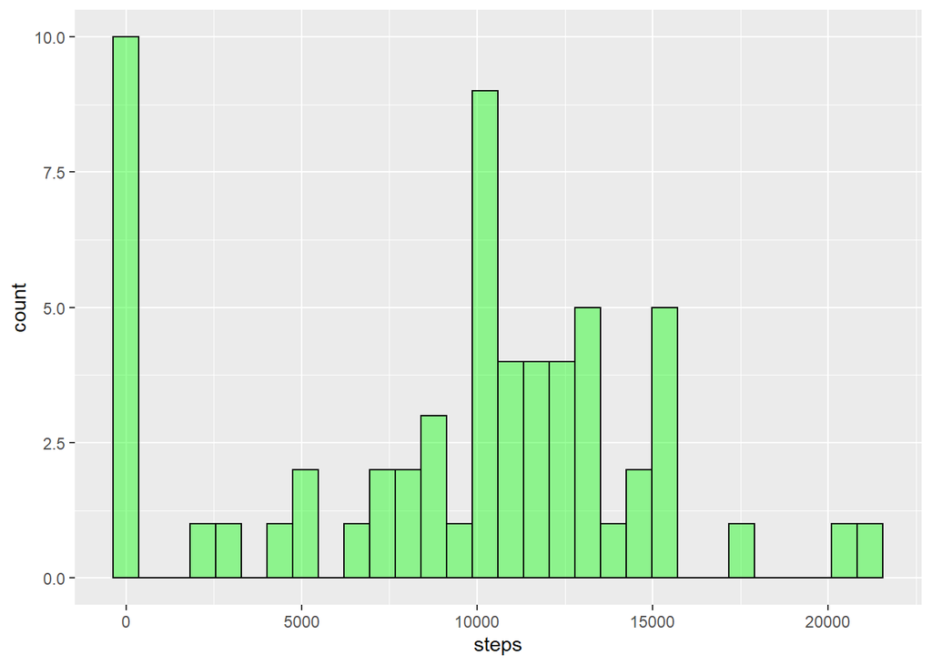

```r
  with(activity_day, ggplot(mapping = aes(steps))+
       geom_histogram(col='black', fill='green', alpha = 0.4))
```

```r
  act_mm_d <- mean(tapply(activity$steps, activity$date, sum), na.rm = T)

  act_mmed_d <- median(tapply(activity$steps, activity$date, sum), na.rm = T)
```

## What is the average daily activity pattern?

1.- Make a time series plot of the 5-minute interval and the average number of steps taken, averaged across all days

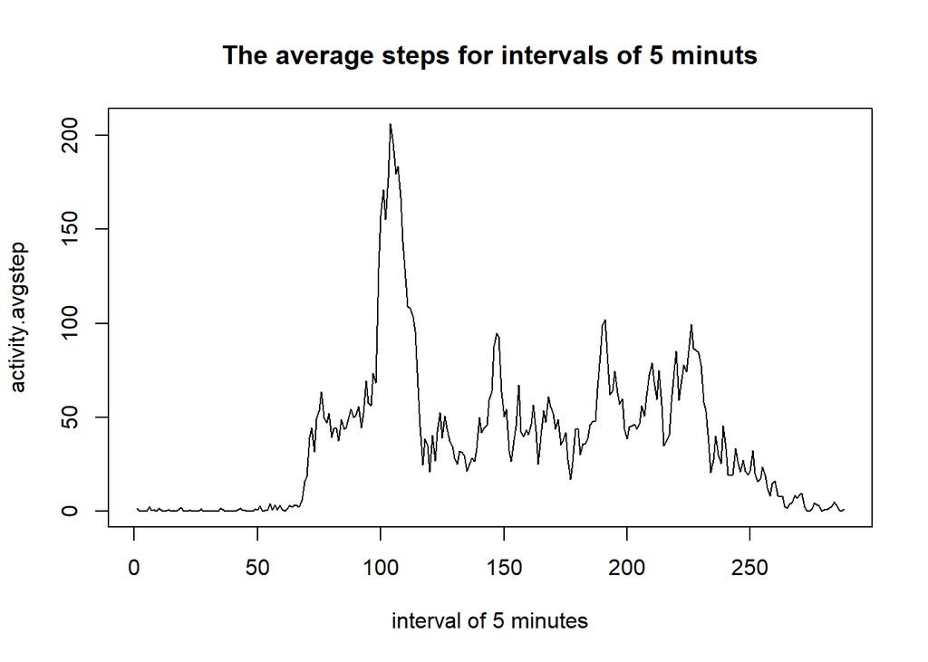

```r
  activity.avgstep <- tapply(activity$steps, activity$interval, mean, na.rm = T)

  plot(activity.avgstep, type = "l", main = "The average steps for intervals of 5 minuts",
     xlab = "interval of 5 minutes")
```

2.-Which 5-minute interval, on average across all the days in the dataset, contains the maximum number of steps?

```r
  maxstep <- which.max(activity.avgstep)
  maxstep
```

```
## 835
## 104
```

## Imputing missing values

1.- Calculate and report the total number of missing values in the dataset (i.e. the total number of rows with NAs.

I calculated the total number of de registers NAs with the summary function, we notated that the colum steps is only that contained this values Na.

```r
  summary(activity)
```

```
##      steps                date          interval
##  Min.   :  0.00   2012-10-01:  288   Min.   :   0.0
##  1st Qu.:  0.00   2012-10-02:  288   1st Qu.: 588.8
##  Median :  0.00   2012-10-03:  288   Median :1177.5
##  Mean   : 37.38   2012-10-04:  288   Mean   :1177.5
##  3rd Qu.: 12.00   2012-10-05:  288   3rd Qu.:1766.2
##  Max.   :806.00   2012-10-06:  288   Max.   :2355.0
##  NA's   :2304     (Other)   :15840
```

I do used library Hmisc for switching the values NA of the colum STEP

I created a copy of activity and change the NA values by the average of the total data.

```r
  activity.copy <- activity

  activity.copy$steps <- impute(activity.copy$steps, mean)

  summary(activity.copy)
```

```
##
##  2304 values imputed to 37.3826
```

```
##      steps                date          interval
##  Min.   :  0.00   2012-10-01:  288   Min.   :   0.0
##  1st Qu.:  0.00   2012-10-02:  288   1st Qu.: 588.8
##  Median :  0.00   2012-10-03:  288   Median :1177.5
##  Mean   : 37.38   2012-10-04:  288   Mean   :1177.5
##  3rd Qu.: 37.38   2012-10-05:  288   3rd Qu.:1766.2
##  Max.   :806.00   2012-10-06:  288   Max.   :2355.0
##                   (Other)   :15840
```

```r
  activity.copy.total.steps <- activity.copy%>%
  group_by(date)%>%
  summarise(total.steps = sum(steps))
```

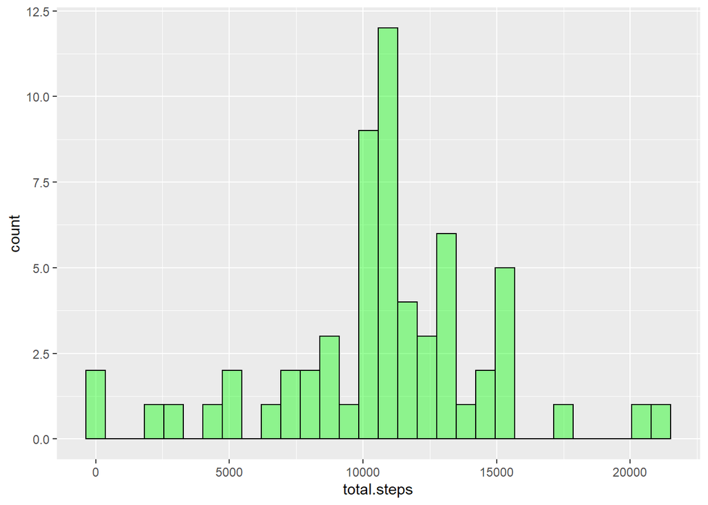

```r
  with(activity.copy.total.steps,ggplot(mapping = aes(total.steps))+
    geom_histogram(col='black', fill='green', alpha = 0.4))
```

## Are there differences in activity patterns between weekdays and weekends?

1.- Create a new factor variable in the dataset with two levels – “weekday” and “weekend” indicating whether a given date is a weekday or weekend day.

I’ll use the pakage lubridate to compared the average number steps taken per 5-minute interval across weekdays and weekends

```r
  library(lubridate)
  activity.copy$date <- as.POSIXct(activity.copy$date)
```

In this part, i added a colum to the copy data frame, called week, this variable contain the week numbers, for example: wednesday is te number 4, sunday is the number 1, etc

```r
  activity.copy <- mutate(activity,week = wday(activity$date))
  activity.weekdays<-activity.copy%>%
    filter(week == 2 | week == 3 | week == 4 | week == 5 | week == 6)

  activity.weekends<-activity.copy%>%
    filter(week == 7 | week == 1)
```

It calculate mean of the two colums, by the weekdays and by the weekends.

```r
  act.weekday.mean <- tapply(activity.weekdays$steps, activity.weekdays$interval, mean, na.rm = T)

 act.weekend.mean <- tapply(activity.weekends$steps, activity.weekends$interval, mean, na.rm = T)
```

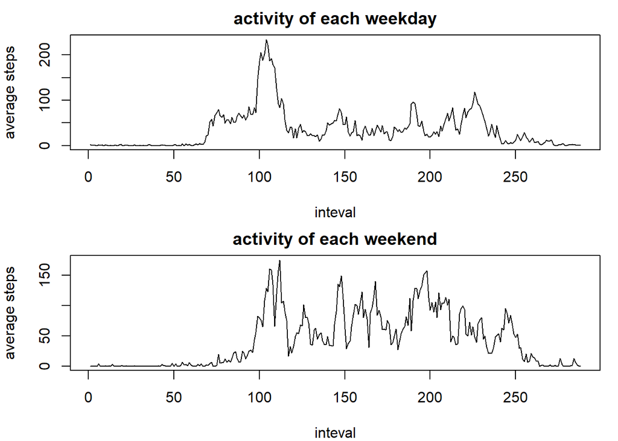

```r
  par(mfrow = c(2,1), mar = c(4,4,2,1))

  plot(act.weekday.mean, type = "l", xlab = "inteval", ylab = "average steps",
     main = "activity of each weekday")

  plot(act.weekend.mean, type = "l", xlab = "inteval", ylab = "average steps",
     main = "activity of each weekend")
```